# Zillow Home Value Prediction Models

## Baseline & Linear Regression

### Baseline Model and Linear Regression Modeling

#### Create a Train/Test Split

The data is split into an 80/20 training test split for training and prediction in the linear model. Then the split data has specified columns converted to factor columns, or converted into categorical data, as the csv did not retain the categorical information because of the categorically encoded nature of the columns. Finally, the parcelID is removed as to leave out some additional noise given by the unique IDs.

```r
data = data_og

#remove the large categorical variables
data = data[-16, -17, -18]

n = nrow(data) #row number
train_index = sample(n, .8 * n) #80% train test split creation index
train_x = data[train_index, ] #index data for training
test_x = data[-train_index, ] #index data for testing
train_y = data$logerror[train_index] #create response variable - training
test_y = data$logerror[-train_index] #create response variable - testing
train_data = data.frame(train_x) #full data training
test_data = data.frame(test_x)  #full data testing


#using only these columns to change into categorical data - makes it a simpler model with only a few categorical encodings rather than hundreds to thousands of columns - fine for our methods here
cols_to_factor = c('ac_type', 'deck', 'tub_or_spa', 'heating_system', 'pool_hot_or_spa', 'patio', 'shed', 'flag_fireplace','tax_delinquency')

train_data[cols_to_factor] = lapply(train_data[cols_to_factor], factor) #apply factor function to selected columns for train
test_data[cols_to_factor] = lapply(test_data[cols_to_factor], factor) #factor selected test columns
train_data = train_data[-1]#remove parcel ID - train
test_data = test_data[-1] #remove Parcel ID - test
train_x = train_x[-1] #remove parcelid train x
test_x = test_x[-1] #remove parcelid test x
```

#### Create A Baseline Model with Linear Regression

```r
baseline_lin_model = glm(logerror ~ ., data = train_x) #create a baseline linear model using glm
summary(baseline_lin_model)

Call:
glm(formula = logerror ~ ., data = train_x)

Deviance Residuals:
    Min       1Q   Median       3Q      Max
-4.6716  -0.0386  -0.0079   0.0243   5.2435

Coefficients:
                   Estimate Std. Error t value Pr(>|t|)
(Intercept)       7.436e-05  2.110e-01   0.000 0.999719
ac_type           2.041e-04  3.082e-04   0.662 0.507739
num_bathroom     -6.804e-03  2.872e-03  -2.369 0.017855 *
num_bedroom       2.047e-03  6.832e-04   2.996 0.002740 **
building_quality -9.816e-04  3.054e-04  -3.214 0.001310 **
deck             -8.726e-03  5.419e-03  -1.610 0.107336
area_total_calc   1.308e-05  1.144e-06  11.439  < 2e-16 ***
num_fireplace    -3.507e-03  1.402e-03  -2.501 0.012372 *
num_full_bath     6.688e-03  2.798e-03   2.390 0.016842 *
tub_or_spa       -1.384e-02  4.657e-03  -2.972 0.002957 **
heating_system    8.443e-04  2.429e-04   3.476 0.000509 ***
latitude         -2.141e-02  2.791e-02  -0.767 0.443027
longitude         1.176e-02  1.911e-02   0.615 0.538309
num_pool         -8.466e-03  1.231e-03  -6.876 6.19e-12 ***
pool_hot_or_spa   6.424e-04  6.171e-03   0.104 0.917097
zoning_landuse    7.350e-04  2.596e-04   2.832 0.004631 **
region_county     5.451e-06  1.658e-06   3.288 0.001008 **
patio            -1.433e-03  3.060e-03  -0.468 0.639514
shed             -2.857e-02  1.418e-02  -2.015 0.043909 *
property_age     -4.607e-05  2.927e-05  -1.574 0.115466
flag_fireplace    1.561e-02  9.307e-03   1.677 0.093526 .
tax_building     -1.016e-08  4.329e-09  -2.347 0.018949 *
tax_total         3.569e-08  3.440e-09  10.374  < 2e-16 ***
tax_property     -3.475e-06  2.779e-07 -12.508  < 2e-16 ***
tax_delinquency   2.287e-02  2.834e-03   8.070 7.09e-16 ***
---
Signif. codes:  0 '***' 0.001 '**' 0.01 '*' 0.05 '.' 0.1 ' ' 1

(Dispersion parameter for gaussian family taken to be 0.02610273)

    Null deviance: 3277.6  on 124951  degrees of freedom
Residual deviance: 3260.9  on 124927  degrees of freedom
AIC: -100914

Number of Fisher Scoring iterations: 2


#==================================================================================================


predictions = predict(baseline_lin_model, data.frame(test_x)) #make predictions with test data specified above
mse = mean((test_y - predictions)**2) #calculate the MSE score from predictions
mae = mean(abs(test_y - predictions)) # produce MAE from predictions
```

#### Results

The baseline model results in an mse of 0.0242259 and and mae of 0.0657223. This means this model predicts within 0.0657223 of the true log error on average throughout the dataset.In terms of the data context - we want to minimize the difference between the estimate price of a given home, and its actual price when the home sold - expressed through the log of each. The linear relationship between many of the variables and the log error is apparent, and so a basic linear model does a pretty good job at producing some accurate or close to accurate predictions.

Is there a model that can further minimize the difference between the estimate and the actual sale price?

#### Improve the Baseline Model by selecting Significant Features

The model can probably be improved by selecting only those varaibles that are significant in predicting the log error from the baseline model. Below the model attempts to capture this idea by only using the significant variables, and only binary encoded categorical variables.

```r
#filter by only numerical data, and significant variables indicated by baseline, rather than with any categorical or full dataset
sig_lin_model = glm(logerror ~ num_bathroom + num_bedroom + building_quality + area_total_calc + num_fireplace + num_full_bath + num_pool + tax_total + tax_property + tax_delinquency, data = train_x)
summary(sig_lin_model)

Call:
glm(formula = logerror ~ num_bathroom + num_bedroom + building_quality +
    area_total_calc + num_fireplace + num_full_bath + num_pool +
    tax_total + tax_property + tax_delinquency, data = train_x)

Deviance Residuals:
    Min       1Q   Median       3Q      Max
-4.6719  -0.0385  -0.0078   0.0243   5.2535

Coefficients:
                   Estimate Std. Error t value Pr(>|t|)
(Intercept)       2.908e-03  2.348e-03   1.238  0.21560
num_bathroom     -4.460e-03  2.504e-03  -1.781  0.07494 .
num_bedroom       1.467e-03  6.224e-04   2.357  0.01841 *
building_quality -9.838e-04  3.048e-04  -3.228  0.00125 **
area_total_calc   1.086e-05  1.014e-06  10.717  < 2e-16 ***
num_fireplace    -3.401e-03  1.171e-03  -2.905  0.00367 **
num_full_bath     4.836e-03  2.477e-03   1.953  0.05086 .
num_pool         -9.725e-03  1.164e-03  -8.352  < 2e-16 ***
tax_total         3.390e-08  3.312e-09  10.236  < 2e-16 ***
tax_property     -3.486e-06  2.753e-07 -12.663  < 2e-16 ***
tax_delinquency   2.274e-02  2.828e-03   8.043 8.87e-16 ***
---
Signif. codes:  0 '***' 0.001 '**' 0.01 '*' 0.05 '.' 0.1 ' ' 1

(Dispersion parameter for gaussian family taken to be 0.02611171)

    Null deviance: 3277.6  on 124951  degrees of freedom
Residual deviance: 3262.4  on 124941  degrees of freedom
AIC: -100885

Number of Fisher Scoring iterations: 2


#==================================================================================================


predictions = predict(sig_lin_model, data.frame(test_x))
mse = mean((test_y - predictions)**2)
mae = mean(abs(test_y - predictions))
```

#### Results

Overall, Linear Regression techniques set a tremendous baseline. The models perform reasonably well with fairly low complexity and straightforward and immediate results.

## Subset Selection

### Using Subset Selection to determine the best fit

#### Create new train/test split for consistency

These subset selection models will use the same train/test split as previously, including categorically encoded categorical variables. It is important to note that in the subset selection model, the categorically encoded variables become one-hot encoded and are modeled as such!

```r
data = data_og # initialize original data

#remove the large categorical variables
data = data[-16, -17, -18]

n = nrow(data) #row number
train_index = sample(n, .8 * n) #80% train test split creation index
train_x = data[train_index, ] #index data for training
test_x = data[-train_index, ] #index data for testing
train_y = data$logerror[train_index] #create response variable - training
test_y = data$logerror[-train_index] #create response variable - testing
train_data = data.frame(train_x) #full data training
test_data = data.frame(test_x)  #full data testing



#using only these columns to change into categorical data - makes it a simpler model with only a few categorical encodings rather than hundreds to thousands of columns - fine for our methods here
cols_to_factor = c('ac_type', 'deck', 'tub_or_spa', 'heating_system', 'pool_hot_or_spa', 'patio', 'shed', 'flag_fireplace','tax_delinquency')

train_data[cols_to_factor] = lapply(train_data[cols_to_factor], factor) #apply factor function to selected columns for train
test_data[cols_to_factor] = lapply(test_data[cols_to_factor], factor) #factor selected test columns
train_data = train_data[-1]#remove parcel ID - train
test_data = test_data[-1] #remove Parcel ID - test
train_x = train_x[-1] #remove parcelid train x
test_x = test_x[-1] #remove parcelid test x
```

#### Methods and Overview

The first model is using forward stepwise selection to create a model in sequential order from the given columns in the data set. In this case the second column chosen for the model is dependent on the first column and so on, so fourth. This method is a quick and effective way to quickly and easily access what variables may perform best in a model - and with the added benefit of possibly decreasing model complexity. The second model is similar, but instead of modeling forward, we model from the last variable to the first in sequential succession. In this case the models produce nearly identical results and suggest using the same variables - but rather than picking variables arbitrarily, the variables that are picked for regression come from the best evaluation score ‘BIC’ from each fit.

We use this method for subset selection instead of Lasso or Ridge methods because they perform reasonably well and give our baseline model a boost. Unfortunately, the complexity in modeling a ridge or lasso method with the intensity of some of the data’s categorical variables makes it cost prohibitive in our case - in which we chose to still use some subset selecction methods, but with more availability in the data wrangling fitting.

#### Forward Selection

```r
regfit.fwd = regsubsets(logerror∼ ., data = train_data, nvmax = 19, method = "forward")

sum_fwd = summary(regfit.fwd)
# sum_fwd
```

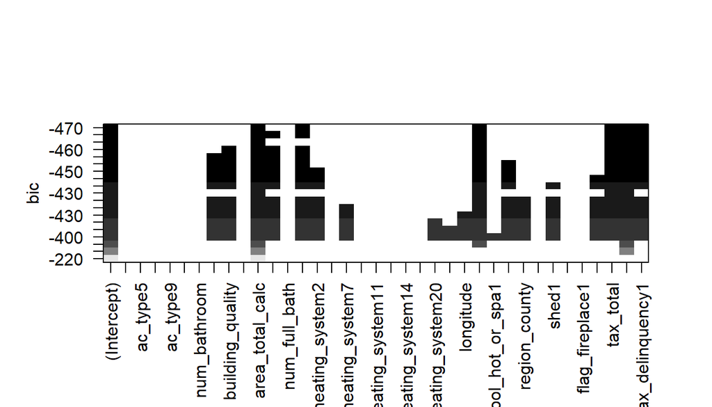

```r
plot(regfit.fwd, scale = 'bic')
```

```r
names(coef(regfit.fwd, 8))
[1] "(Intercept)"      "building_quality" "area_total_calc"  "num_fireplace"
[5] "tub_or_spa1"      "num_pool"         "tax_total"        "tax_property"
[9] "tax_delinquency1"
```

#### Backward Selection

```r
regfit.bwd = regsubsets(logerror ∼ ., data = train_data, nvmax = 19, method = "backward")

sum_bwd = summary(regfit.bwd)
# sum_bwd
```

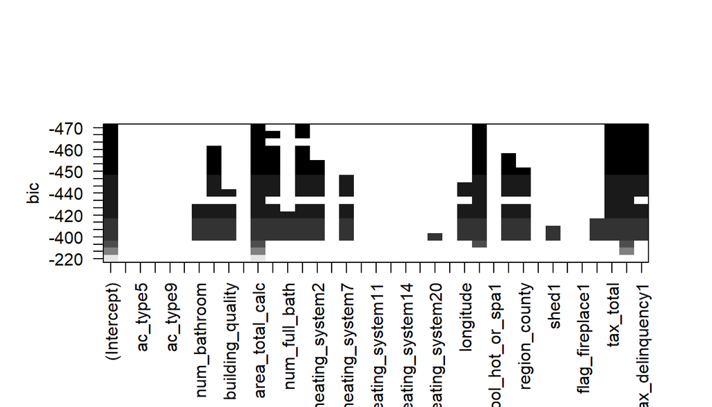

```r
plot(regfit.bwd, scale = 'bic')
```

```r
names(coef(regfit.bwd, 7))
[1] "(Intercept)"      "area_total_calc"  "num_fireplace"    "tub_or_spa1"
[5] "num_pool"         "tax_total"        "tax_property"     "tax_delinquency1"
```

#### Regression Using Subset Selected Variables

```r
lin_subset_selection = glm(logerror ~  + area_total_calc + num_fireplace + tub_or_spa + num_pool + tax_total + tax_property + tax_delinquency + tax_building, data = train_x)

#model below is for different data - data without the same categorical columns
# lin_subset_selection = glm(logerror ~ building_quality + area_total_calc + tub_or_spa + num_pool + tax_total + tax_property + tax_delinquency, data = train_x)

summary(lin_subset_selection)

Call:
glm(formula = logerror ~ +area_total_calc + num_fireplace + tub_or_spa +
    num_pool + tax_total + tax_property + tax_delinquency + tax_building,
    data = train_x)

Deviance Residuals:
    Min       1Q   Median       3Q      Max
-4.6702  -0.0382  -0.0075   0.0244   5.2504

Coefficients:
                  Estimate Std. Error t value Pr(>|t|)
(Intercept)     -2.603e-03  1.058e-03  -2.461 0.013875 *
area_total_calc  1.438e-05  7.533e-07  19.096  < 2e-16 ***
num_fireplace   -3.853e-03  1.143e-03  -3.372 0.000748 ***
tub_or_spa      -1.173e-02  3.074e-03  -3.817 0.000135 ***
num_pool        -8.246e-03  1.154e-03  -7.148 8.87e-13 ***
tax_total        2.936e-08  3.399e-09   8.637  < 2e-16 ***
tax_property    -3.098e-06  2.760e-07 -11.226  < 2e-16 ***
tax_delinquency  1.761e-02  2.801e-03   6.287 3.24e-10 ***
tax_building    -1.052e-08  4.150e-09  -2.535 0.011249 *
---
Signif. codes:  0 '***' 0.001 '**' 0.01 '*' 0.05 '.' 0.1 ' ' 1

(Dispersion parameter for gaussian family taken to be 0.02572527)

    Null deviance: 3228.8  on 124951  degrees of freedom
Residual deviance: 3214.2  on 124943  degrees of freedom
AIC: -102750

Number of Fisher Scoring iterations: 2
predictions = predict(lin_subset_selection, test_x)
mse = mean((test_y - predictions)**2)
mae = mean(abs(test_y - predictions))
```

## Gradient Boosting

### Using Gradient Boosting for Regression

In the model below, we use boosting methods on the data to try and branch away from simple linear regressions. We ended up selecting boosting because it is a more advanced method for regression and can be easily done within a few lines of code. Boosting is also reasonably straightforward, and since it uses decision trees, the model can more reliably and comfortably take some instense categorical variables as inputs and produce a good result. Boosting is also really a first step into tree methods, with a random forest method being the end goal - It gives us a good benchmar. Additionally, using gradient boosting techniques for regression introduces tunable paramters and control, as well as implements a more advance technique for regression methods over linear regression. Finally, this is the first of the ensemble methods employed for this dataset, and will serve as a good benchmark for the next ensemble method planned - Regression with Random Forest

#### Train/Test Split

```r
data = data_og # initialize original data

n = nrow(data)
train_index = sample(n, .8 * n)
train_x = data[train_index, ]
test_x = data[-train_index, ]
train_y = data$logerror[train_index]
test_y = data$logerror[-train_index]
train_data = data.frame(train_x)
test_data = data.frame(test_x)

cols_to_factor = c('ac_type', 'deck', 'tub_or_spa', 'heating_system', 'zoning_landuse', 'region_city', 'region_county', 'pool_hot_or_spa', 'patio', 'shed', 'flag_fireplace','tax_delinquency')#only some of the categorical

train_data[cols_to_factor] = lapply(train_data[cols_to_factor], factor)
test_data[cols_to_factor] = lapply(test_data[cols_to_factor], factor)
train_data = train_data[-1] #remove parcel ID - train
test_data = test_data[-1] #remove Parcel ID - test
```

#### Boosting Model

```r
# boosting
gbm.out <- gbm(logerror ~ ., distribution = "gaussian",interaction.depth = 3,
               n.trees = 1000, shrinkage = 0.001, data = train_x)
gbm.pred <- predict.gbm(gbm.out,newdata=test_x, n.trees = 1000)
gbm.mse <- mean((gbm.pred-test_y)^2)
print(paste0('gbm Model training MSE: ', gbm.mse))
[1] "gbm Model training MSE: 0.0259755433258037"

mae = mean(abs(test_y - gbm.pred))
```

#### Results

The boosting model produces an mse of 0.0259755 and an mae of 0.0658451. The model performs pretty well, and gives us a result on par with earlier models, but with the option to tune the parameters more and engineer successful scenarios. This model performs comparitively, so for now, it’s parameters will remain as they are shown.

## Random Forest

We chose Random Forest Regression because it is an advanced method for regression that gives a large amount of control over tunable paramters and learns and predicts very well. We expect this model to perform the best, as well as produce a variable importance plot used to gain some additional insight about the data.

### Advanced Regression Modeling with Random Forests

#### Train/Test Split

This split is the same as the boosting model, and uses all categorical variables in the model to perform regression.

```r
data = data_og # initialize original data

n = nrow(data)
train_index = sample(n, .8 * n)
train_x = data[train_index, ]
test_x = data[-train_index, ]
train_y = data$logerror[train_index]
test_y = data$logerror[-train_index]
train_data = data.frame(train_x)
test_data = data.frame(test_x)

cols_to_factor = c('ac_type', 'deck', 'tub_or_spa', 'heating_system', 'zoning_landuse', 'region_city', 'region_county', 'pool_hot_or_spa', 'patio', 'shed', 'flag_fireplace','tax_delinquency')#only some of the categorical

train_data[cols_to_factor] = lapply(train_data[cols_to_factor], factor)
test_data[cols_to_factor] = lapply(test_data[cols_to_factor], factor)
train_data = train_data[-1] #remove parcel ID - train
test_data = test_data[-1] #remove Parcel ID - test
```